# Exploring Advantages of Using TopPIC for Top-down MS Proteomics through Ovarian Cancer Data

Zhige (Daniel) Wang

[Link to website](https://todanielwang.github.io/projects/datascience/milestone1.html)

## Project Goals

As the title suggests, the goal of this project is to use the public ovarian cancer dataset, a set of data that's well-regarded as good Top-down MS-based raw data, and use TopPIC, a tool created and maintained by our own lab, to do the general pipeline of workflow and analysis said raw data and lastly obtaining a list of proteoform identifications. Similar with all other available tools, TopPIC will have it's pros and cons as to the type of raw data it can identify the most, and so this project aims to explore what exactly those pros and cons are in comparsion to other major tools such as MSPathFinder or ProSight

## Project Background

This project of course deals with the minor field of Top-down MS-based proteomics, but it's core is still about the performance of a certain analytical tool, hence very little biological knowledge is required to understand the meaningfulness of this project. Dispite that, I still need to explain a little more on this field and what exactly TopPIC does. The computer science/informatics side of modern-day proteomics is inherently about protein and proteoform (different modifications of the same protein) identification. That is to say, given a sample of proteins, we need to figure out what this sample consists of, more specifically, what's the amino acid sequence of the proteins in the sample.

Top-down MS-based proteomics is one approach to this problem, that we take advantage of a machinery known as the mass spectrometry (MS), which is an analytical technique that is used to measure the mass-to-charge(m/z) ratio of ions. These m/z ratios would allow us to uniquely identify proteins/proteoforms using database search. But of course, in practice, the unique condition becomes a little rusty as noise and imprecision of the machinery comes into play while having to deal with huge computational complexity of searching through a database in millions of terms. And hence computational tools such as TopPIC were introduced to deal with these problems, that it would take the raw data generated by (MS), and return a set of protein/proteoform identifications.

Now there are essentially two things that defines a spectrum (unit of raw data), and impacts the database search. The MS1 feature, also known as precursor feature, and MS2 fragments, also known as peak list. Explaining why they act the way they are will dive into deep biology, so I will directly explain how they impact each other. The list of possbile precursor features needs to be first identified through a process known as feature detection, which is handled by TopFD, a part of the the TopPIC Suite. Then each spectra need to be manually assigned a precursor feature, which includes precursor mass, precursor charge, and adjusted precursor m/z. Identifiying the full list of precurosr and properly assign them to the spectra is crucial that they also play a part in identifying the list of peaks, which is what's searched against the database.

## Project Datasets

This dataset can be found at MassIVE using the unique identifier MSV000080257 or accessed through this [link](https://massive.ucsd.edu/ProteoSAFe/dataset.jsp?task=d95d54a09d894022b033f3fc058ee95b). Do note that the datasets cannot be direclty downloaded through the browser, but through a FTP. And of course, this is 20 GB of public data for which is too much data to do a total analysis on, so we focus on a randomly chosen file labeled as CPTAC_Intact_rep1_15Jan15_Bane_C2-14-08-02RZ. And again, since this data is the raw data produced by the MS, we must run it through the Top-down search pipeline first to obtain data we need.

We will first run the raw dataset through a tool called MSConvert, which converts the raw data into a generally accepted format known as mzML, which is raw data parsed into xml with certain places compressed into hexadecimal incodings. We will then do feature detection using TopFD, a part of the TopPIC Suite, which would output us ms1.feature, ms2.feature, and ms2.align files. The first two files are tsv files under the hood which we will be looking at the first file. The last file is a txt file with certain structure that we standardized for database search. These three files will then be used as input to TopPIC, which performs the database search and will output many different result files, and we are particularly interested in prsm_single.tsv.

Out of this process, there are two files that we will be looking at with close attetion. Namely ms1.feature, and prsm_single.tsv. As mentioned before, it's very important that we are assigning the correct precursor feature to each spectra, that a wrongly assigned precursor will likely to cause a difference in the peak list, but also possibly provide the wrong identification. Hence we must be looking at both the identification results and the list of features.

Some of questions we will be answering through the project is: what type of spectra, or more specifically, what range of precursor are we more likely to identify and assign correctly. Is there even a preference in precursor selection at all, or does it have to more with the datasets? What spectra are we missing in comparsion to other tools in the field, such as MSPathFinder or ProSight (for which I need to run the identification process using their tools) and is there a trend as to the ones that we missed.

## ETL (Extraction, Transform, and Load)

There will not be much ETL happening as all data are generated using analytical tools developed, though I will drop a couple columns that's not very useful for me. And I might want to turn ms2.align file, the input for database search into a data table of some kind but it's rather difficult as it not tidy at all due the list of ms2 fragments, which can vary in size from 0 to maybe 100 fragments, but currently that's not of much interest for me. Though prsm_single.tsv does indeed have a header, which are the parameters for the tool, that which I removed so that it can properly read by pandas as a tsv.

```python
import pandas as pd
from matplotlib import pyplot as plt

#importing ms1 features and dropping useless columns
ms1_feature = pd.read_csv("./data/CPTAC_Intact_rep1_15Jan15_Bane_C2-14-08-02RZ_ms1.feature", delimiter="\t", index_col="ID")
ms1_feature.drop(columns=["Sample_ID", "Minimum_fraction_id", "Maximum_fraction_id"], inplace=True)
display(ms1_feature)
display(ms1_feature.dtypes)


#importing result prsm_single.tsv and dropping useless columns
prsm_df = pd.read_csv("./data/CPTAC_Intact_rep1_15Jan15_Bane_C2-14-08-02RZ_ms2_toppic_prsm_single.tsv", delimiter="\t", index_col="Prsm ID")
prsm_df.drop(columns=["Data file name", "Spectrum-level Q-value", "Proteoform-level Q-value", "Fragmentation", "MIScore", "Spectrum ID"], inplace=True)
display(prsm_df)
display(prsm_df.dtypes)
```

| ID | Mass | Intensity | Time_begin | Time_end | Apex_time | Apex_intensity | Minimum_charge_state | Maximum_charge_state |
| --- | --- | --- | --- | --- | --- | --- | --- | --- |
| 0 | 2883.627925 | 3.327920e+09 | 5522.36 | 6150.23 | 5558.36 | 3.772398e+08 | 3 | 7 |
| 1 | 4960.498156 | 3.321628e+09 | 4258.23 | 4702.81 | 4294.94 | 3.303075e+08 | 3 | 9 |
| 2 | 3640.970182 | 3.718496e+09 | 8917.85 | 9245.73 | 8960.28 | 3.051384e+08 | 2 | 7 |
| 3 | 2884.621125 | 3.006718e+08 | 5522.36 | 5567.46 | 5567.46 | 3.005344e+08 | 5 | 6 |
| 4 | 4958.519580 | 2.883442e+08 | 4302.92 | 4302.92 | 4302.92 | 2.883442e+08 | 6 | 6 |
| ... | ... | ... | ... | ... | ... | ... | ... | ... |
| 21328 | 1521.242530 | 3.656400e+02 | 1549.77 | 1549.77 | 1549.77 | 3.656400e+02 | 2 | 2 |
| 21329 | 1072.100150 | 3.134200e+02 | 1560.69 | 1560.69 | 1560.69 | 3.134200e+02 | 1 | 1 |
| 21330 | 1336.933400 | 3.398200e+02 | 1690.85 | 1690.85 | 1690.85 | 3.398200e+02 | 1 | 1 |
| 21331 | 1548.398490 | 3.414000e+02 | 909.86 | 909.86 | 909.86 | 3.414000e+02 | 1 | 1 |
| 21332 | 1222.444990 | 2.346100e+02 | 1484.75 | 1484.75 | 1484.75 | 2.346100e+02 | 1 | 1 |

21333 rows × 8 columns

```
Mass                    float64
Intensity               float64
Time_begin              float64
Time_end                float64
Apex_time               float64
Apex_intensity          float64
Minimum_charge_state      int64
Maximum_charge_state      int64
dtype: object
```

| Prsm ID | Scan(s) | Retention time | #peaks | Charge | Precursor mass | Adjusted precursor mass | Proteoform ID | Feature intensity | Feature score | Feature apex time | ... | Proteoform mass | Protein N-terminal form | Fixed PTMs | #unexpected modifications | unexpected modifications | #variable PTMs | variable PTMs | #matched peaks | #matched fragment ions | E-value |
| --- | --- | --- | --- | --- | --- | --- | --- | --- | --- | --- | --- | --- | --- | --- | --- | --- | --- | --- | --- | --- | --- |
| 0 | 1401 | 2171.03 | 14 | 5 | 2850.72708 | 2850.713095 | 969 | 359200.0 | -1000.000000 | 2113.83 | ... | 2850.713095 | NONE | NaN | 0 | NaN | 0 | NaN | 5 | 5 | 1.789750e-05 |
| 1 | 1450 | 2247.02 | 38 | 7 | 4188.24456 | 4188.229560 | 1131 | 3380000.0 | -1000.000000 | 2684.51 | ... | 4188.229560 | NONE | NaN | 1 | +6.0135:[4-14] | 0 | NaN | 15 | 12 | 5.681957e-04 |
| 2 | 1464 | 2268.68 | 54 | 8 | 4188.24431 | 4188.229310 | 562 | 3380000.0 | -1000.000000 | 2684.51 | ... | 4188.229310 | NONE | NaN | 1 | +15.9976:[2] | 0 | NaN | 14 | 13 | 1.921897e-05 |
| 3 | 1500 | 2324.37 | 35 | 6 | 4188.24506 | 4188.230060 | 1131 | 3380000.0 | -1000.000000 | 2684.51 | ... | 4188.230060 | NONE | NaN | 1 | +6.0140:[3-14] | 0 | NaN | 12 | 11 | 5.824503e-03 |
| 4 | 1517 | 2349.98 | 27 | 5 | 2722.63015 | 2722.620150 | 668 | 610300.0 | -1000.000000 | 2363.33 | ... | 2722.620150 | NONE | NaN | 1 | -128.0929:[28-29] | 0 | NaN | 10 | 8 | 4.151128e-03 |
| ... | ... | ... | ... | ... | ... | ... | ... | ... | ... | ... | ... | ... | ... | ... | ... | ... | ... | ... | ... | ... | ... |
| 3072 | 8002 | 10780.79 | 138 | 7 | 8449.14567 | 8449.144873 | 48 | 4671000.0 | 39.257481 | 10788.62 | ... | 8449.144873 | NME_ACETYLATION | NaN | 0 | NaN | 0 | NaN | 60 | 55 | 1.111600e-28 |
| 3073 | 8004 | 10783.43 | 140 | 9 | 8770.82649 | 8770.802281 | 923 | 2107000.0 | -1000.000000 | 10768.07 | ... | 8770.802281 | NONE | NaN | 0 | NaN | 0 | NaN | 15 | 14 | 5.694920e-06 |
| 3074 | 8006 | 10786.04 | 89 | 5 | 5847.20025 | 5846.202900 | 1031 | 464700.0 | -1000.000000 | 10788.62 | ... | 5846.202900 | NONE | NaN | 1 | +23.9567:[1-5] | 0 | NaN | 21 | 17 | 6.572753e-05 |
| 3075 | 8007 | 10787.34 | 134 | 7 | 8769.82200 | 8770.802281 | 923 | 2107000.0 | -1000.000000 | 10768.07 | ... | 8770.802281 | NONE | NaN | 0 | NaN | 0 | NaN | 13 | 10 | 2.069100e-04 |
| 3076 | 8009 | 10791.07 | 126 | 6 | 8449.16503 | 8449.144873 | 48 | 4671000.0 | 39.257481 | 10788.62 | ... | 8449.144873 | NME_ACETYLATION | NaN | 0 | NaN | 0 | NaN | 45 | 42 | 6.851500e-25 |

3077 rows × 28 columns

```
Scan(s)                        int64
Retention time               float64
#peaks                         int64
Charge                         int64
Precursor mass               float64
Adjusted precursor mass      float64
Proteoform ID                  int64
Feature intensity            float64
Feature score                float64
Feature apex time            float64
#Protein hits                  int64
Protein accession             object
Protein description           object
First residue                  int64
Last residue                   int64
Special amino acids          float64
Database protein sequence     object
Proteoform                    object
Proteoform mass              float64
Protein N-terminal form       object
Fixed PTMs                   float64
#unexpected modifications      int64
unexpected modifications      object
#variable PTMs                 int64
variable PTMs                float64
#matched peaks                 int64
#matched fragment ions         int64
E-value                      float64
dtype: object
```

These two will be the dataset we are working with for now. And we can briefly look at the quality of the search results from their E-value, which is a performance valuation we created to show how good of a match the current spectrum is to a proteoform in the databse. The closer this value is to 0, the better.

```
0.00044567942044492837
```

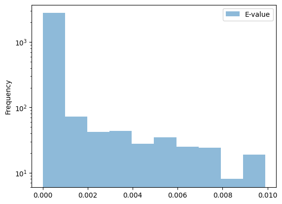

```python
display(prsm_df["E-value"].mean())
prsm_df["E-value"].plot.hist(alpha=.5, legend=True, log=True)
```

And very clearly we can see our data is very skewed towards the right, which is essentially the case for all data, but we can still see that most of our data is fairly good.